# NLP: Social Media Case Study

**Note**: This notebook is illustrative only and cannot be run. For an interactive version, please visit the [Colab Notebook](https://colab.research.google.com/drive/1BsUuTn0sXbNUw2H6thcq8Fwu08-ibYrm?usp=sharing)

## I. Introduction

Data scientists frequently split data into two categories: structured and unstructured data. The former is the traditional kind of data used by engineers because it fits neatly into the row and column databases used by so many websites and softwares. However, unstructured data is far more messy and difficult for a machine to store, analyze, and interpret. The data generated from coversation, articles, and social media can carry lots of useful information, but these are all examples of unstructured data, so they are difficult to manipulate. However, recent advances in machine learning have allowed us to not only take advantage of this data, but also build models that can understand the meaning behind the words in the texts themselves.  
**Natural language processing (NLP)** is a field of machine learning that gives the machines the ability to read, understand and derive meaning from human language. There are many use cases for NLP, some of which you may even use on a daily basis! Siri, Alexa, and other digital assistants rely on NLP models to understand the requests posed to them, and to formulate responses in a way that is natural for human language. On the corporate level, businesses can take advantage of NLP algorithms to analyze social media data to understand the sentiment consumers have about their products.  
In this case study, we will explore major concepts in NLP through analyzing user tweets, and then build a model to automatically generate tweets in the likeness of an existing account!

## II. Invoking APIs

There are two primary ways we can acquire data from the internet. The first one is web scraping, which we explored in great detail in [this notebook](https://colab.research.google.com/drive/1x1w6TSVLiWBOWI78XAZwxTQ9VkYTiypL?usp=sharing). We rely on web scraping when a site does not provide a way for us to directly acquire their data, so we have to scrape it off their webpage instead.

However, sometimes a site will provide a method to programmatically access and utilize its data in the form on an API. An **Application Programming Interface (API)** is a method in which different servers can talk to one another using *requests*. For example, if you go on Google and search "weather in houston", Google sends a request to weather.com's API asking for weather information in `Houston, TX`. The API processes this request internally, and returns weather data to Google, who displays it on their search page for you to view.

But why would companies just provide their data externally? Typically, this data and API service are packaged as a product, and those who query an API are usually charged for the service. For this reason, when you call an API, you often have to authenticate yourself with some kind of unique token; this key lets the API know who you are, much like a username and password on a user-facing website.

To generate the data for this case study, we will make use of the [Twitter API](https://developer.twitter.com/en/docs/twitter-api) to retrieve tweets!

To retrieve tweets, first we have to authenticate ourselves with a token. This token is from my Twitter Dev account, and I will be rotating it so it will not work after today's session. However, if you would like to continue to play with the API, you can [sign up](https://developer.twitter.com/en/apply-for-access) to generate your own credentials!

```python
os.environ['BEARER_TOKEN'] = '<insert token here>'
```

Once we have our token specified, we can send a request to the API in two ways. The first is through the command line:

```python
!curl -X GET\
 -H "Authorization: Bearer $BEARER_TOKEN"\
  "https://api.twitter.com/1.1/statuses/user_timeline.json?screen_name=elonmusk&count=1"
```

```
[{"created_at":"Sun Oct 11 20:33:17 +0000 2020","id":1315390031851257856,"id_str":"1315390031851257856","text":"@enn_nafnlaus When Eberhard was fired from the Tesla CEO role in mid 2007 for providing false information to me & t… ","truncated":true, rel="nofollow">Twitter for iPhone<\/a>","in_reply_t…
```

Alternatively, we can also use python's `requests` library:

```python
def get_tweets(username, num_tweets, include_rts=False, exclude_replies=True):

    url = ('https://api.twitter.com/1.1/statuses/user_timeline.json?screen_name={}&count={}&include_rts={}&exclude_replies={}'
           .format(username,
                   num_tweets,
                   str(include_rts).lower(),
                   str(exclude_replies).lower()))

    header = {'Authorization': 'Bearer {}'.format(os.environ.get('BEARER_TOKEN'))}

    response = requests.get(url, headers=header)
    if response.status_code == 200:
        return response.json()

    return None
```

```python
print(get_tweets('elonmusk', 1, include_rts=True, exclude_replies=False))
```

[output not shown]

Let's dissect the important parts of this API call:

1. `curl`/`requests`: `curl` is the commmand to make a request to an API, while `requests` is the python package built for this purpose.
2. `GET`/`get()`: This is specifying the request method, in this case a `GET` request. We use this kinds of request method when we'd like to retrieve information from the server. There are [other request methods](https://www.tutorialspoint.com/http/http_methods.htm) as well. For example, a `POST` request is used to send data to the server.
3. `-H`/`headers`: This is the flag used to specify that we would like to send our request with a header. This allows us to pass additional information to the server that is unrelated to the data we are sending. For example, here we are using the header to authenticate ourselves with our token.
4. URL paramters: We use the parameters in the URL to specify what data we are looking for from the server. In this case we used parameters `screen_name` and `count` with values `elonmusk` and `1`, respectively. URL parameters are like arguments in a method header, and you can refer to the documentation of an API to see what parameters are accepted. For example, [here](https://developer.twitter.com/en/docs/twitter-api/v1/tweets/timelines/api-reference/get-statuses-user_timeline) is the documentation for the `statuses/user_timeline` API endpoint we are calling.

## III. Tweet Scraping and Sentiment Analysis

Now that we know how API's work, let's use the Twitter API to generate some tweet data! For this example, we will be using Jeff Bezos' Twitter account, [@JeffBezos](https://twitter.com/JeffBezos).

As you can see above, the output for each Tweet is a verbose `JSON` containing lots of data that isn't relevant for us. Let's modify this data by retaining only the fields we care about and then converting it from a list of `JSON` to a `pandas DataFrame`:

```python
def json_to_df(response_json):
    if response_json:
        output = []
        for tweet in response_json:
            clean_tweet = {}
            clean_tweet['created_at'] = tweet['created_at']
            clean_tweet['id'] = tweet['id']
            clean_tweet['text'] = tweet['text']
            clean_tweet['favorite_count'] = tweet['favorite_count']
            clean_tweet['retweet_count'] = tweet['retweet_count']
            output.append(clean_tweet)

  return pd.DataFrame(output)
```

```python
try:
    response_json = get_tweets('JeffBezos', 500, include_rts=False, exclude_replies=True)
    df = json_to_df(response_json)
except:
    df = pd.read_csv('drive/My Drive/course_dependencies/datasets/JeffBezos_tweets.csv')
```

```python
print('Number of Jeff Bezos\' Tweets retrieved: {}'.format(len(df)))
```

```
Number of Jeff Bezos' Tweets retrieved: 185
```

```python
df.head()
```

|  | created_at | id | text | favorite_count | retweet_count |
| --- | --- | --- | --- | --- | --- |
| 0 | Fri Feb 28 17:17:58 +0000 2020 | 1233441223232245760 | Discussing climate, sustainability, and preser... | 16079 | 1385 |
| 1 | Mon Feb 03 02:16:32 +0000 2020 | 1224154674804084736 | I just took a DNA test, turns out I’m 100% @li... | 90386 | 10473 |
| 2 | Wed Jan 29 17:30:21 +0000 2020 | 1222572705066536961 | Hey, Alexa — show everyone our upcoming Super ... | 13838 | 2047 |
| 3 | Wed Jan 22 19:03:20 +0000 2020 | 1220059386694922240 | #Jamal https://t.co/8ej1rUBXVb | 31667 | 5448 |
| 4 | Mon Jan 20 03:04:23 +0000 2020 | 1219093283265138688 | Hey, India. We’re rolling out our new fleet of... | 61356 | 9140 |

Here we have our data, a 185 of Bezos' tweets, stored as a `DataFrame`. The reason we only retrieved 185 tweets despite querying for 500 is that the API filtered out all retweets and replies as per our request. This will keep our data clean.

Our NLP models will attempt to use the choice of words and their orderings to decipher an understanding as to what information is being conveyed. However, these models are incredibly sensitive to the input they are given; for example, a model is not clever enough to understand that a URL in itself doesn't convey meaning, or that 'college' and '#college' are basically the same thing. So, to increase our algorithms' ability to understand, we have to clean tweets by stripping and simplifying certain elements.

```python
def clean_tweet(tweet):

    tweet = re.sub(r'http\S+', '', tweet)           #Remove URLs
    tweet = re.sub(r'@[a-zA-Z0-9_]+', '', tweet)    #Remove @ mentions
    tweet = tweet.strip(" ")                        #Remove whitespace resulting from above
    tweet = re.sub(r' +', ' ', tweet)               #Remove redundant spaces
    tweet = re.sub('#', '', tweet)                  #Remove '#' hash tag
    tweet = re.sub('RT[\s]+', '', tweet)            #Remove RT (retweet)

    # Handle common HTML entities
    tweet = re.sub(r'&lt;', '<', tweet)
    tweet = re.sub(r'&gt;', '>', tweet)
    tweet = re.sub(r'&amp;', '&', tweet)

    return tweet
```

```python
df['clean_text'] = df['text'].apply(clean_tweet)
df
```

|  | created_at | id | text | favorite_count | retweet_count | clean_text |
| --- | --- | --- | --- | --- | --- | --- |
| 0 | Fri Feb 28 17:17:58 +0000 2020 | 1233441223232245760 | Discussing climate, sustainability, and preser... | 16078 | 1384 | Discussing climate, sustainability, and preser... |
| 1 | Mon Feb 03 02:16:32 +0000 2020 | 1224154674804084736 | I just took a DNA test, turns out I’m 100% @li... | 90384 | 10473 | I just took a DNA test, turns out I’m 100% ’s ... |
| 2 | Wed Jan 29 17:30:21 +0000 2020 | 1222572705066536961 | Hey, Alexa — show everyone our upcoming Super ... | 13838 | 2047 | Hey, Alexa — show everyone our upcoming Super ... |
| 3 | Wed Jan 22 19:03:20 +0000 2020 | 1220059386694922240 | #Jamal https://t.co/8ej1rUBXVb | 31666 | 5448 | Jamal |
| 4 | Mon Jan 20 03:04:23 +0000 2020 | 1219093283265138688 | Hey, India. We’re rolling out our new fleet of... | 61355 | 9141 | Hey, India. We’re rolling out our new fleet of... |
| ... | ... | ... | ... | ... | ... | ... |
| 180 | Sun Jun 19 00:23:58 +0000 2016 | 744324811191525377 | Thanks @VirginGalactic! So agree space needs a... | 526 | 150 | Thanks ! So agree space needs all of us. Grada... |
| 181 | Fri Jun 17 13:58:37 +0000 2016 | 743805050254819328 | And of course – development test flight – anyt... | 190 | 49 | And of course – development test flight – anyt... |
| 182 | Fri Jun 17 13:55:47 +0000 2016 | 743804334396170240 | Look for one-chute-out test starting about 7 m... | 214 | 76 | Look for one-chute-out test starting about 7 m... |
| 183 | Fri Jun 17 13:52:42 +0000 2016 | 743803559150391298 | Watching a rocket launch (and rocket landing!)... | 283 | 86 | Watching a rocket launch (and rocket landing!)... |
| 184 | Fri Jun 17 13:49:25 +0000 2016 | 743802731924594688 | New Shepard launch set for Sunday at 10:15 am ... | 422 | 327 | New Shepard launch set for Sunday at 10:15 am ... |

185 rows × 6 columns

Now that we have cleaned the tweets, we can use a package called `TextBlob` to understand some aspects of a tweet's sentiment. First we will look into *polarity*, which quantifies the emotion of a tweet. The metric is a value in the range of $[-1.0, 1.0]$, where positive and negative values denote positive and negative sentiment, respectively, and the absolute value denotes the magnitude of the emotion. Another sentiment we can observe is *subjectivity*, how factual or opinionated a tweet is. This metric is a value in the range of $[0.0, 1.0]$; generally, the lower the value, the more objective the statement.

As you can see below, for us getting these sentiments is as easy as a single line of code. But how is `TextBlob` computing these values? Behind the scenes, this package uses a trained **Recurrent Neural Network (RNN)** which takes the words in these tweets as input and predicts their sentiments by attempting to understand the meaning of the text. We will dive into the details of RNNs in the next section.

```python
def get_subjectivity(tweet):
    return TextBlob(tweet).sentiment.subjectivity

def get_polarity(tweet):
    return TextBlob(tweet).sentiment.polarity

def get_sentiment(score):
    if score < -0.1:
        return 'Negative'
    elif score > 0.1:
        return 'Positive'
    else:
        return 'Neutral'
```

```python
df['subjectivity'] = df['clean_text'].apply(get_subjectivity)
df['polarity'] = df['clean_text'].apply(get_polarity)
df['sentiment'] = df['polarity'].apply(get_sentiment)
df
```

|  | created_at | id | text | favorite_count | retweet_count | clean_text | subjectivity | polarity | sentiment |
| --- | --- | --- | --- | --- | --- | --- | --- | --- | --- |
| 0 | Fri Feb 28 17:17:58 +0000 2020 | 1233441223232245760 | Discussing climate, sustainability, and preser... | 16078 | 1384 | Discussing climate, sustainability, and preser... | 0.400000 | 0.100000 | Neutral |
| 1 | Mon Feb 03 02:16:32 +0000 2020 | 1224154674804084736 | I just took a DNA test, turns out I’m 100% @li... | 90384 | 10473 | I just took a DNA test, turns out I’m 100% ’s ... | 0.000000 | 0.000000 | Neutral |
| 2 | Wed Jan 29 17:30:21 +0000 2020 | 1222572705066536961 | Hey, Alexa — show everyone our upcoming Super ... | 13838 | 2047 | Hey, Alexa — show everyone our upcoming Super ... | 0.433333 | 0.291667 | Positive |
| 3 | Wed Jan 22 19:03:20 +0000 2020 | 1220059386694922240 | #Jamal https://t.co/8ej1rUBXVb | 31666 | 5448 | Jamal | 0.000000 | 0.000000 | Neutral |
| 4 | Mon Jan 20 03:04:23 +0000 2020 | 1219093283265138688 | Hey, India. We’re rolling out our new fleet of... | 61355 | 9141 | Hey, India. We’re rolling out our new fleet of... | 0.454545 | 0.136364 | Positive |
| ... | ... | ... | ... | ... | ... | ... | ... | ... | ... |
| 180 | Sun Jun 19 00:23:58 +0000 2016 | 744324811191525377 | Thanks @VirginGalactic! So agree space needs a... | 526 | 150 | Thanks ! So agree space needs all of us. Grada... | 0.200000 | 0.250000 | Positive |
| 181 | Fri Jun 17 13:58:37 +0000 2016 | 743805050254819328 | And of course – development test flight – anyt... | 190 | 49 | And of course – development test flight – anyt... | 0.000000 | 0.000000 | Neutral |
| 182 | Fri Jun 17 13:55:47 +0000 2016 | 743804334396170240 | Look for one-chute-out test starting about 7 m... | 214 | 76 | Look for one-chute-out test starting about 7 m... | 0.100000 | 0.000000 | Neutral |
| 183 | Fri Jun 17 13:52:42 +0000 2016 | 743803559150391298 | Watching a rocket launch (and rocket landing!)... | 283 | 86 | Watching a rocket launch (and rocket landing!)... | 0.266667 | 0.037500 | Neutral |
| 184 | Fri Jun 17 13:49:25 +0000 2016 | 743802731924594688 | New Shepard launch set for Sunday at 10:15 am ... | 422 | 327 | New Shepard launch set for Sunday at 10:15 am ... | 0.477273 | 0.136364 | Positive |

185 rows × 9 columns

Here is the resulting `DataFrame`. To make it more readable, a sentiment tag has also been added. Tweets that have `polarity` values with a magnitude less than $0.1$ aren't particularly positive or negative, so are tagged as neutral. With these tags, we can count how many tweets are positive, negative, and neutral. We can also use the scores to see which tweets are the most positive and negative.

```python
df = df.sort_values(by=['polarity'],ascending=False).reset_index(drop=True)
pos_tweet = df['text'][0]
neg_tweet = df['text'][len(df)-1]

print(df['sentiment'].value_counts())
print('\n Most positive tweet: \n {}'.format(pos_tweet))
print('\n Most negative tweet: \n {}'.format(neg_tweet))
```

```
Positive    111
Neutral      68
Negative      6
Name: sentiment, dtype: int64

 Most positive tweet:
 This is a gigantic compliment to our teams. Best of luck Haggler in your continuing adventures. #CustomerObsession https://t.co/LyGg3aD5QM

 Most negative tweet:
 Here’s escape vid in slow mo. #InFlightEscape https://t.co/MrKRiHZu8Y
```

```python
def sentiment_plot(df):
    for i in range(0, df.shape[0]):
        plt.scatter(df["polarity"][i], df["subjectivity"][i], color='Blue')

    plt.title('Sentiment Analysis')
    plt.xlabel('Polarity')
    plt.ylabel('Subjectivity')
    plt.show()
```

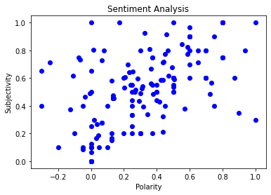

```python
sentiment_plot(df)
```

```python
def build_word_cloud(df):
    corpus = ' '.join([tweet for tweet in df['clean_text']])
    word_cloud = WordCloud(width=500, height=300, random_state=42, max_font_size=110).generate(corpus)

    plt.imshow(word_cloud, interpolation="bilinear")
    plt.axis('off')
    plt.show()
```

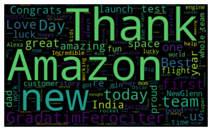

```python
build_word_cloud(df)
```

```python
def visualize_tweets(username,num_tweets=100):
    response_json = get_tweets(username, num_tweets)
    if response_json:
      df = json_to_df(response_json)
      df['clean_text'] = df['text'].apply(clean_tweet)
      df['subjectivity'] = df['clean_text'].apply(get_subjectivity)
      df['polarity'] = df['clean_text'].apply(get_polarity)
      sentiment_plot(df)
      build_word_cloud(df)
```

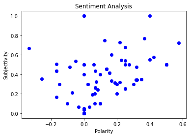

[figure not shown]

```python
visualize_tweets('CNN',100)
```

## IV. Recurrent Neural Networks

Traditional neural networks are proficient in completing tasks where the input features are semi-independent from one another. For example, predicting a person's height based on their gender and age is a task this algorithm can sufficiently complete, because gender and age are independent of one another. However, for problems with sequential inputs, such as text, this assumption is invalid because any given word is dependent on the ones before it.  
This is where RNN's come into play. **Recurrent neural networks (RNNs)** are a class of neural networks that allow previous outputs to be used as inputs while having hidden states. RNNs are called *recurrent* because they perform the same task for every element of a sequence, with the output being depended on the previous computations. Another way to think about RNNs is that they have a “memory” which captures information about what has been calculated so far. The figure below illustrates the architecture of a simple RNN.

[figure not shown]

The left side is traditional RNN notation, but it is hard to understand what exactly is taking place. The right side shows the RNN being "unfurled", so that the network's state for each step in the sequence is revealed. For example, if we had a sequence of three words, we would unroll this RNN into three layers, one for each word. Let's break this network down piece by piece.  
$x(t)$: This is the input for the network at time step $t$. In the case of the three word input sequence, $x(1)$ would be the first word, $x(2)$ would be the second, and so on.  
$h(t)$: This represents the *hidden state* of the network at time $t$. The hidden state is a trademark of the RNN, and is vital since it acts as the "memory" of the network. The hidden state at time $t$ is computed as,

$h(t) = f(\begin{bmatrix}b & U & W \end{bmatrix} \begin{bmatrix}1 \\ x(t) \\ h(t-1) \end{bmatrix})$

where $f$ is a non-linear transformation, such as the *tanh* or *reLU* functions, and $b$, $U$ and $W$ are weights that will be tuned when training the algorithm (note that $h(0)$ is typically defined as a random integer between $0$ and $1$).  
$o(t)$: This is the output of the network at time $t$. This value is computed as,

$o(t) = \begin{bmatrix}c & V \end{bmatrix} \begin{bmatrix}1 \\ h(t) \end{bmatrix}$

where $c$, and $V$ are weights that will be tuned when training the algorithm. Some implementations may also pass all outputs through some non-linear transformation, or just the final output.  
Let's put it all together with a simple example. Suppose I have a vocabulary consisting of only the words ["ate", "cat", "food", "the"]. I provide my network this vocabulary along with the text sequence "the cat ate". at timestep $t$, the network takes as input word $t$ in the text sequence and outputs a probability score for each word in the vocabulary. For example, at timestep 1, the RNN will receive "the" as input and guess the likelihood for each word in the vocabulary to come next. Luckily, in the next time step it is given the next word, so it can train itself to guess these probabilities in an intelligent way. This process will repeat itself until it gets to the last word, "ate", and predicts probability scores for each word in the vocabulary. We can then take the one with the highest score and use it as our output. You can then repeat this process by passing the network it's own guess as an input and have it generate another word. This is a simplified explanation of how an RNN can generate text.

Explanation adapted from this [textbook](http://www.deeplearningbook.org/contents/rnn.html).

## V. Tweet Generation

Now that we have a high level understanding of how RNN's work, we are going to use one to generate tweets. First we need to get some training data and package it up into a file. Luckily, we have already created methods to retrieve tweets and clean them, so this is pretty straightforward:

```python
def write_to_file(username, num_tweets):
    response_json = get_tweets(username, num_tweets)
    if response_json:
        df = json_to_df(response_json)
        df['clean_text'] = df['clean_text'].apply(clean_tweet)

        corpus = ' '.join([tweet for tweet in df['clean_text']])
        #sanitize text by removing non ascii characters
        corpus = corpus.encode("ascii", errors="ignore").decode()

        file_name = username + '_' + str(count)
        with open(file_name  + '.txt', 'a') as f:
            f.write(corpus)
```

Now we can train an RNN to generate tweets. `textgenrnn` is a python package that is fantastic for this purpose, since it will build and train a model according to our specifications.

First, we configure the architecture of the model. RNN's can be used to generate text on either a character level or a word level. Word level models require a lot more data than their counterparts, and therefore take much longer to train. We also need to configure the size of the RNN's hidden state embedding, and the number of layers in the RNN. If we are limited on training data we can allow our RNN to predict text forwards and backwards to increase the number of examples; however, this is discouraged if we can just generate more training data (which we can by scraping more tweets). Finally, we can set the length of the input sequence, and restrict the size of the vocabulary if our RNN is a word lebel model.

Once the model is fully specified, we need to configure training parameters. The number of epochs signifies how many times the model will be trained with the full dataset. The larger the number of epochs, the more accurate the model but also the longer it will take to train. We can also configure the training to validation ratio, dropout, and validation parameters to increase the model's ability to generalize.

Once we have fully specified the architecture of the model and training procedure, we can begin to train the model!

```python
def train_model(model_name, file_name=model_name, rnn_size=128, rnn_layers=3, num_epochs=20,batch_size=1024,dim_embeddings=100):
    file_name = file_name + '.txt'

    model_cfg = {
      'word_level': False,          # set to True if want to train a word-level model (more data/ smaller max_length)
      'rnn_size': rnn_size,         # number of LSTM cells of each layer (128/256 recommended)
      'rnn_layers': rnn_layers,     # number of LSTM layers (>=2 recommended)
      'rnn_bidirectional': False,   # consider text both forwards and backward, can give a training boost
      'max_length': 30,             # number tokens to consider before predicting\(20-40 for characters, 5-10 for words)
      'max_words': 10000,           # maximum number of words to model; the rest will be ignored (word-level model only)
      }

    train_cfg = {
      'line_delimited': False,      # set to True if each text has its own line in the source file
      'num_epochs': num_epochs,     # set higher to train the model for longer
      'gen_epochs': 5,              # generates sample text from model after given number of epochs
      'train_size': 0.8,            # proportion of input data to train on: setting < 1.0 limits model from learning perfectly
      'dropout': 0.0,               # ignore random proportion of source tokens each epoch, allowing model to generalize better
      'validation': False,          # If train__size < 1.0, test on holdout dataset; will make overall training slower
      'is_csv': False               # set to True if file is a CSV exported from Excel/BigQuery/pandas
      }

    #create new textgenrnn model
    textgen = textgenrnn(name=model_name)

    #train model using tweets file and prespecified parameters
    train_function = textgen.train_from_file if train_cfg['line_delimited'] else textgen.train_from_largetext_file
    train_function(
      file_path=file_name,
      new_model=True,
      num_epochs=train_cfg['num_epochs'],
      gen_epochs=train_cfg['gen_epochs'],
      batch_size=batch_size,
      train_size=train_cfg['train_size'],
      dropout=train_cfg['dropout'],
      validation=train_cfg['validation'],
      is_csv=train_cfg['is_csv'],
      rnn_layers=model_cfg['rnn_layers'],
      rnn_size=model_cfg['rnn_size'],
      rnn_bidirectional=model_cfg['rnn_bidirectional'],
      max_length=model_cfg['max_length'],
      dim_embeddings=dim_embeddings,
      word_level=model_cfg['word_level'])
```

Now we can use the trained model to generate tweets! One issue commonly faced with text generation is that conservative models may output the same or similar text repetitively because the model because those words are ones the model is more confident about. For example,

> is that they were all the same thing that was a startup is that they were all the same thing that was a startup is that they were all the same thing that was a startup is that they were all the same

To alleviate this issue we introduce the `temperature` hyperparameter; higher values of this parameter allow the model to be more diverse with its vocabulary choice at the risk of making more mistakes. Like most other things in machine learning, setting the correct temperature value is a tradeoff between accuracy and diversity. Generally, a value between $0.1$ and $1.0$ is recommended.

```python
def generate_tweets(username, count, n=5, temperature=0.2):
    model_name = username + '_' + str(count)

    #train model if unable to locate weight, vocab, and config files
    if not (path.exists('{}_weights.hdf5'.format(model_name))
          and path.exists('{}_vocab.json'.format(model_name))
          and path.exists('{}_config.json'.format(model_name))):
    write_to_file(username, count)
    train_model(model_name)

    #load model and generate tweets
    textgen = textgenrnn(weights_path='{}_weights.hdf5'.format(model_name),
                      vocab_path='{}_vocab.json'.format(model_name),
                      config_path='{}_config.json'.format(model_name))
    tweets = textgen.generate(n=n, temperature=temperature, return_as_list=True)

    return tweets
```

Let's see if we can generate tweets that look like those of CNN 📰

```python
tweets = generate_tweets('CNN',1000,temperature=0.3)
```

```python
for i, tweet in enumerate(tweets):
    print('Tweet {}: {} \n'.format(str(i), tweet[tweet.find(' ')+1:]))
```

```
Tweet 0: stay at home. But the company says it will be allowed to reopen the coronavirus pandemic to finally acknowledge the coronavirus pandemic to travel businesses to remove Confederate officers in the US are some of the country are allowed to do so. The country is also all the test that can kill…

Tweet 1: protests against police brutality and the country are also protesting for an investigation into the death of George Floyd at the hands of US police officers have been reported in the US. The US may have seen a senior memorial of George Floyd at the hands of US police officers involved in th…

Tweet 2: pandemic today: Sign up to get the facts from CNN delivered to your inbox daily: Here's everything you need to know about the coronavirus pandemic today: Sign up to get the facts from CNN delivered to your inbox daily: We don't know what you're not going to be able to pay at a return to th

Tweet 3: was determined to be a public backlash after he suggested men are better than the realities to continue to reopen the protests that they continue to stay home and state and local coronavirus cases in the US and Canada is not giving its workform to help the economic deployment of the coronav…

Tweet 4: at the hands of US police officers have been removed from the state's new coronavirus restrictions, according to a new study A town hall Covid-19 shows how to see if it was a fundamental coronavirus relief funding to the streets to come to some of his busiest and the economy in the country …
```

## VI. Exercise

Recall that we generated a dataset of Amazon reviews for various headphones in the [Web Scraping notebook](https://colab.research.google.com/drive/1x1w6TSVLiWBOWI78XAZwxTQ9VkYTiypL?usp=sharing). Use these reviews to generate your own!

```python
reviews_df = pd.read_csv('drive/My Drive/course_dependencies/datasets/amazon_reviews.csv')
reviews_df.head(5)
```

|  | Unnamed: 0 | product | user | stars | location | date | popularity | title | text |
| --- | --- | --- | --- | --- | --- | --- | --- | --- | --- |
| 0 | 0 | beats | Minnesota Mike | 4 | United States | 4/9/2018 | 2,141 | Superb Bluetooth range, very comfortable, grea... | I never thought I would purchase a set of Beat... |
| 1 | 1 | beats | J.L. | 4 | United States | 10/5/2017 | 1,142 | I thought Beats were supposed to suck? | Just got the Studio 3s this week in Shadow Gre... |
| 2 | 2 | beats | Matthew Schmitz | 5 | United States | 4/17/2018 | 321 | The Beats Studio 3 are a welcome upgrade to th... | I wanted to start off this brief review by sta... |
| 3 | 3 | beats | Trig Triggler | 1 | United States | 11/9/2018 | 204 | Support on these is Awful | I really really regret buying these.First thou... |
| 4 | 4 | beats | Scalloped91 | 1 | United States | 9/26/2018 | 139 | Don’t buy these headphones. They are built to ... | This is the second pair I have had fail in the... |

```python
#Step one: write a method that writes the `text` column in `reviews_df` to a text file
def reviews_to_text_file(df, file_name):
  #code goes here (nothing should be returned)
```

```python
def generate_reviews(reviews_df, model_name, rnn_size, rnn_layers, num_epochs, batch_size, dim_embeddings, temperature):
    file_name = 'reviews'
    if not path.exists(file_name + '.txt'):
    reviews_to_text_file(reviews_df, file_name)

    #train new model if model weights not found
    if not (path.exists('{}_weights.hdf5'.format(model_name))
          and path.exists('{}_vocab.json'.format(model_name))
          and path.exists('{}_config.json'.format(model_name))):
    train_model(model_name,
                file_name=file_name,
                rnn_size=rnn_size,
                rnn_layers=rnn_layers,
                num_epochs=num_epochs,
                batch_size=batch_size,
                dim_embeddings=dim_embeddings)

    #load existing model and generate tweets
    textgen = textgenrnn(weights_path='{}_weights.hdf5'.format(model_name),
                      vocab_path='{}_vocab.json'.format(model_name),
                      config_path='{}_config.json'.format(model_name))

    n = 5 #no modification allowed!
    tweets = textgen.generate(n=n, temperature=temperature, return_as_list=True)
```

```python
#Step two: play with these hyperparameters to try to generate the most realistic review!
rnn_size = #128 or 256
rnn_layers = #at least 2
num_epochs = #higher = increased training, lower = faster
batch_size = #at least 128, higher = more data per epoch, lower = faster
dim_embeddings = #at least 40, higher = more nuanced understanding of vocab, lower = faster
temperature = #(0,1], higher = more creative/unpredictable

#verify valid configuration
assert rnn_size == 128 or rnn_size == 256
assert type(rnn_layers) == int and rnn_layers >= 2
assert type(num_epochs) == int and num_epochs > 0
assert type(batch_size) == int and batch_size >= 128
assert type(dim_embeddings) == int and dim_embeddings >= 40
assert type(temperature) == float and temperature > 0 and temperature <= 1

model_name = 's{}_l{}_e{}_b{}_d{}_t{}'.format(str(rnn_size),
                                              str(rnn_layers),
                                              str(num_epochs),
                                              str(batch size),
                                              str(dim_embeddings),
                                              str(temperature))
reviews = generate_reviews(reviews_df, model_name, rnn_size, rnn_layers, num_epochs, batch_size, dim_embeddings, temperature)
```

```python
for i, review in enumerate(reviews):
  print('Generated Review {}: {} \n'.format(str(i), review[review.find(' ')+1:]))
```